# Model evaluation and analysis: the *modEvA* R package in a nutshell

A. Marcia Barbosa (https://modtools.wordpress.com)

updated 25 Sep 2026

*modEvA* is an R package for **analysing and evaluating species distribution models**. Most functions are meant for generalized linear models (GLMs) with binomial distribution and a logit link function (i.e., logistic regression), although many can be applied to other models as well. Most functions can also be applied to values of observed and corresponding predicted values (both in a table or as raster predictions and presence point observations), as long as they are bounded between 0 and 1.

## Installing and loading *modEvA*

The *modEvA* package works within the free and open-source R statistical software, so you first need to **download, install and open R** (available at http://www.r-project.org). In this tutorial, in `monospaced` font are the commands that you need to type (or copy and paste) into the R console (and then press the *enter* key to execute them). For commands that generate visible results in R, these are usually shown below them, preceded by hash marks (##). Note that all **commands are case-sensitive**, so you must respect upper- and lower-case letters; that you must always use **straight** (`'`, `"`) **rather than curly quotes and apostrophes**; and that **R is only ready to receive a new command when there’s a prompt sign (>) at the end of the R console**; if not, it’s still waiting for an operation to be finished or for you to complete a previous command – watch out for unclosed parentheses and such.

**Install the latest version of *modEvA*** by pasting the command below in the R console (when connected to the internet):

```r
install.packages("modEvA", repos="http://R-Forge.R-project.org")
```

You only need to install the package once (unless a new version becomes available), but you need to **load it every time you open a new R session** in which you intend to use *modEvA* (no need for an internet connection anymore), by pasting the following command in R:

```r
library(modEvA)
```

## Analysing models

Load the *rotif.mods* sample dataset (based on a global dataset of rotifer distribution records originally published with [this article](http://onlinelibrary.wiley.com/doi/10.1111/j.1600-0587.2011.06850.x/abstract)) to use as an example:

```r
data(rotif.mods)
```

You can **get more information on this dataset** (the following command should open an R Documentation window):

```r
help(rotif.mods)
```

You can see that *rotif.mods* is a list containing two elements: a list of *models* and a dataframe with their *predictions*. Let’s leave the predictions alone for now, and work on the model objects. Let’s start by checking out their names:

```r
names(rotif.mods$models)
```

```
##  [1] "Abrigh" "Afissa" "Apriod" "Bangul" "Bcalyc" "Bplica" "Bquadr" "Burceo"
##  [9] "Cgibba" "Edilat" "Flongi" "Kcochl" "Kquadr" "Ktropi" "Lbulla" "Lclost"
## [17] "Lhamat" "Lluna"  "Llunar" "Lovali" "Lpatel" "Lquadr" "Mventr" "Ppatul"
## [25] "Pquadr" "Pvulga" "Specti" "Tpatin" "Tsimil" "Ttetra"
```

These names correspond to species codes, and each object in this list is a GLM of the presence-absence of the corresponding species. Now let’s **assign the first model to an individual object**, and use it **to try out *modEvA* functions**. The following alternate commands should both create a model object named “mod” from the 1st model in the *rotif.mods$models* list, which is named “Abrigh”:

```r
mod <- rotif.mods$models[[1]]
mod <- rotif.mods$models[["Abrigh"]]
```

In most *modEvA* functions, instead of a model object, you can provide vectors of observed and predicted values, or presence points and raster predictions, that you’ve obtained elsewhere. Let’s extract such values from this model, to be able to use them in the examples as well:

```r
mydata <- data.frame(observed = mod$y, predicted = mod$fitted.values)
```

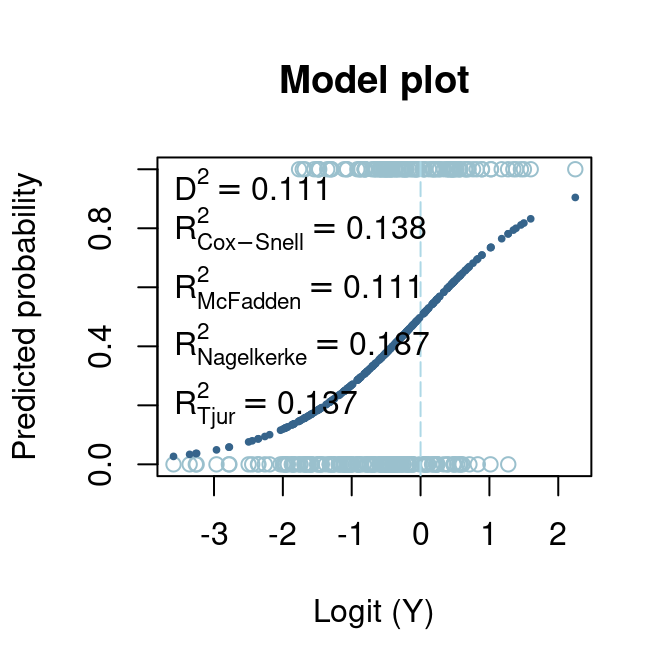

```r
plotGLM(model = mod, xlab = "Logit (Y)", ylab = "Predicted probability", main = "Model plot")
```

**Instead of the *model* object**, you can provide your **observed and predicted values**:

```r
plotGLM(obs = mydata[ , "observed"], pred = mydata[ , "predicted"], xlab = "Logit (Y)", ylab = "Predicted probability", main = "Model plot")
```

## Evaluating discrimination capacity

Let’s now **calculate the area under the ROC curve (AUC)** for this model. The *AUC* function produces the plot displayed below and also some text results, which will appear in your R console but will not be shown here. Again, as in most *modEvA* functions, you can provide *obs = mydata[ , “observed”], pred = mydata[ , “predicted”]* instead of *model = mod*; or you can provide a raster map of your predictions and a set of spatial points of the presence observations to compare these predictions with.

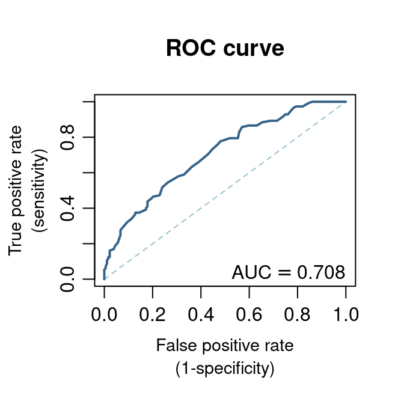

```r
AUC(model = mod, main = "ROC curve")
```

You can also plot and compute the area under the **precision-recall curve**:

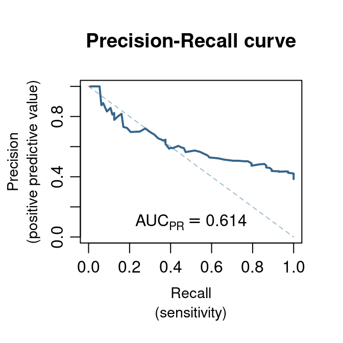

```r
AUC(model = mod, curve = "PR", main = "Precision-Recall curve")
```

Now **compute some threshold-based evaluation measures** for this model, using maximum TSS (i.e. the best balance between sensitivity and spcificity) as the threshold value above which to consider that the model predicts the species to be present. Only the plot is shown here, but additional text results should appear in your R console as well:

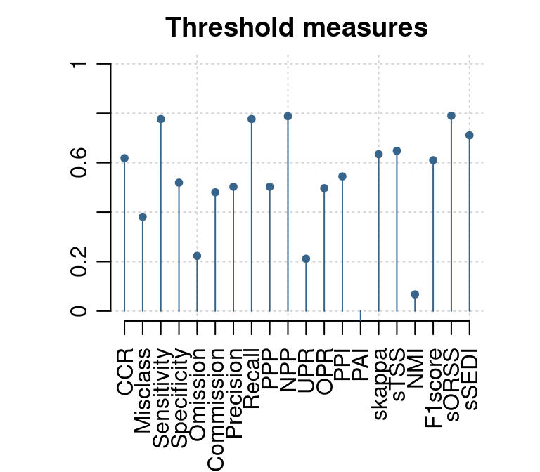

```r
par(mar = c(5.6, 4.1, 2, 2.1))  # changes figure margins
threshMeasures(model = mod, thresh = "maxTSS", ylim = c(0, 1), main = "Threshold measures")
```

Note that there are many **different criteria for choosing the `thres`hold** value for a model (see Details in `help(threshMeasures)`). Let’s **see how each threshold-based measure varies** along **with** the chosen prediction **threshold**, to identify optimal thresholds according to different criteria:

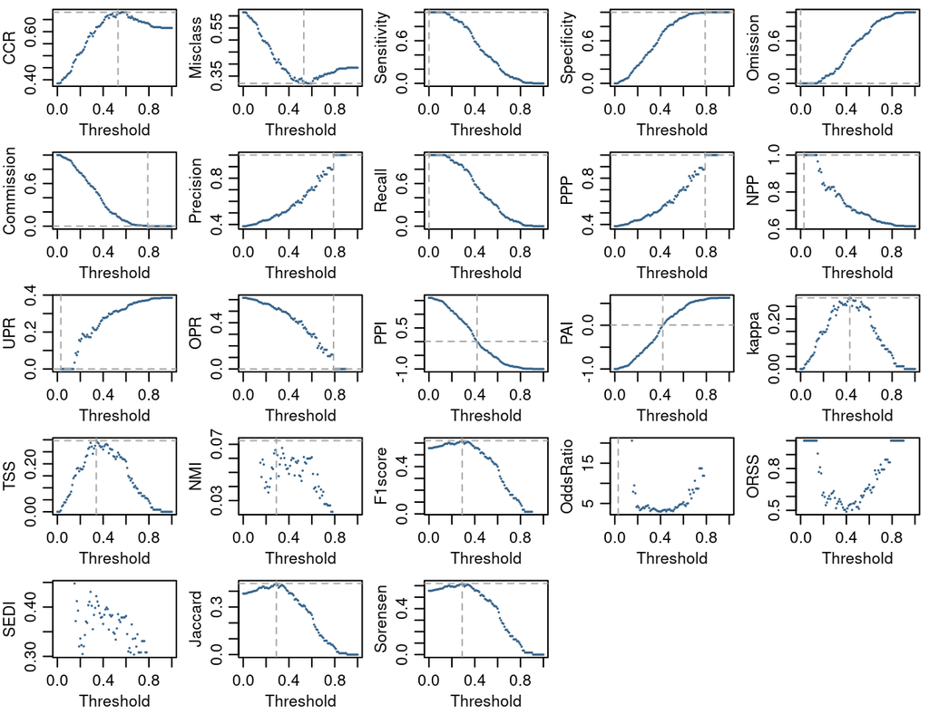

```r
optiThresh(model = mod, pch = 20, cex = 0.2)
```

You can also compute the **optimal threshold balancing two complementary evaluation measures**:

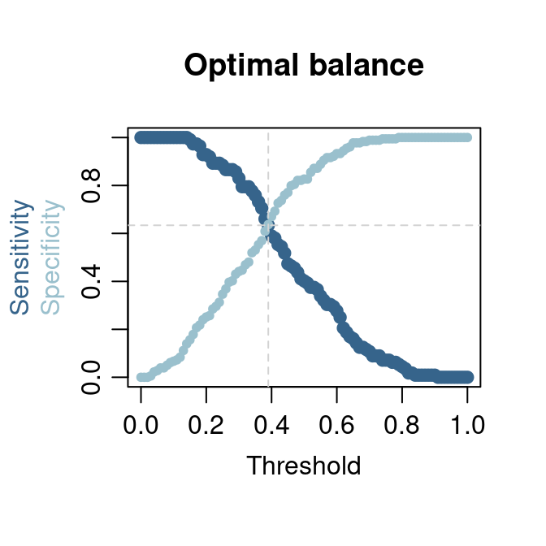

```r
optiPair(model = mod, measures = c("Sensitivity", "Specificity"), main = "Optimal balance")
```

## Assessing model explanatory power, fit and calibration

Let’s now assess the **proportion of variation that the model accounts for**. For GLMs there isn’t a single consensual measure for this; *modEvA* can calculate the **explained deviance** (*D-squared*), optionally adjusted for the number of observations and parameters; and some **pseudo R-squared** values (see `help(Dsquared)`and `help(RsqGLM)` for further info):

```r
Dsquared(model = mod)
```

```
## [1] 0.1114199
```

```r
Dsquared(model = mod, adjust = TRUE)
```

[output not shown]

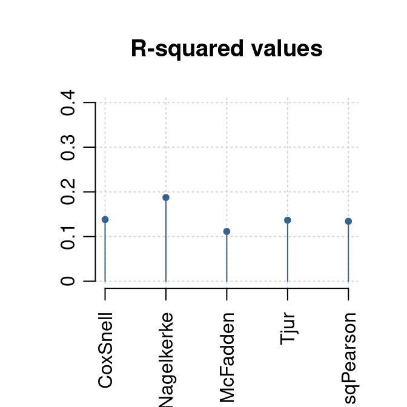

```
## $CoxSnell
## [1] 0.1380008
##
## $Nagelkerke
## [1] 0.187434
##
## $McFadden
## [1] 0.1114199
##
## $Tjur
## [1] 0.1365661
##
## $sqPearson
## [1] 0.134168
```

```r
RsqGLM(model = mod, ylim = c(0, 0.4), main = "R-squared values")
```

We can also take a look at some model calibration measures, such as **Miller’s calibration statistics**, the **Continuous Boyce Index** and the **Hosmer-Lemeshow goodness-of-fit**. Note, however, that the first one is not useful for evaluating a model on the same data used for building it (the results will look perfect by definition); and that the latter two can depend strongly on the *bin.method* used for grouping the values. See `help(Miller)`, `help(Boyce)` and `help(HLfit)` to find out how these measures are calculated and how their results can be interpreted.

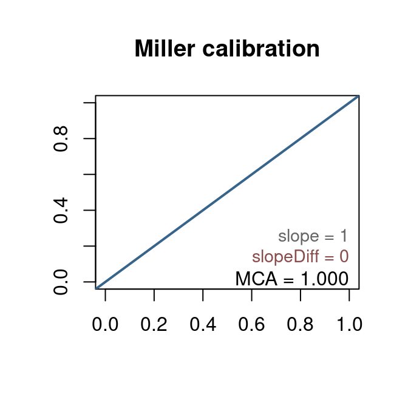

```r
Miller(model = mod)
```

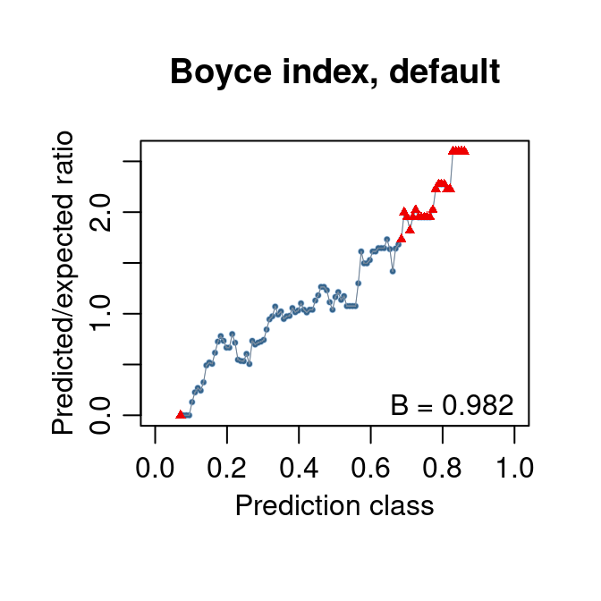

```r
Boyce(model = mod, bin.method = "quantiles", main = "Boyce index, default")
```

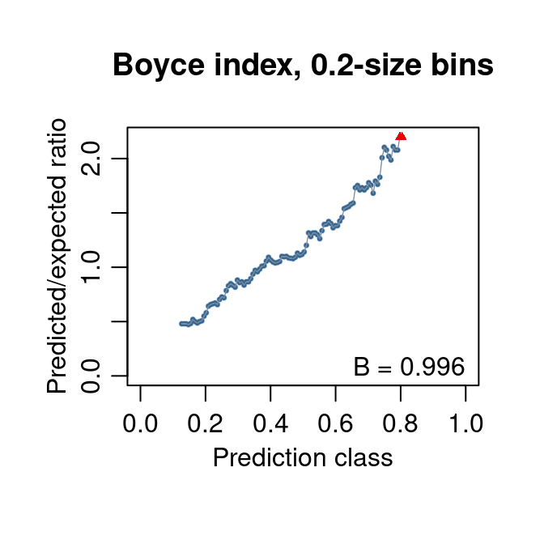

```r
Boyce(model = mod, bin.width = 0.2, main = "Boyce index, 0.2-size bins")
```

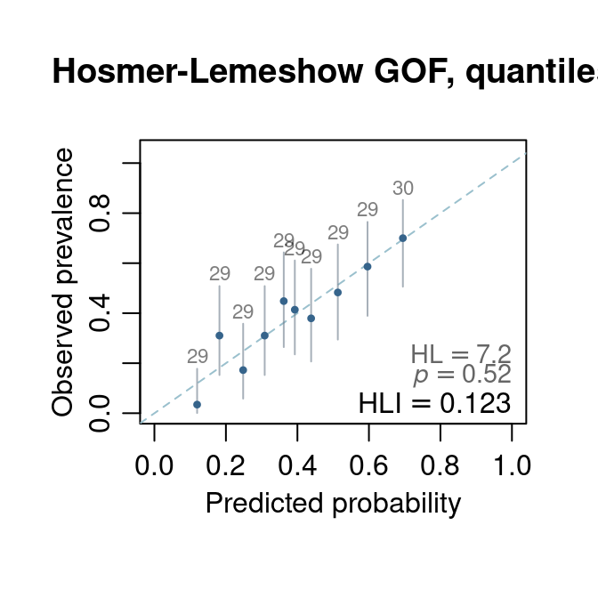

```r
HLfit(model = mod, bin.method = "quantiles", main = "Hosmer-Lemeshow GOF, quantiles")
```

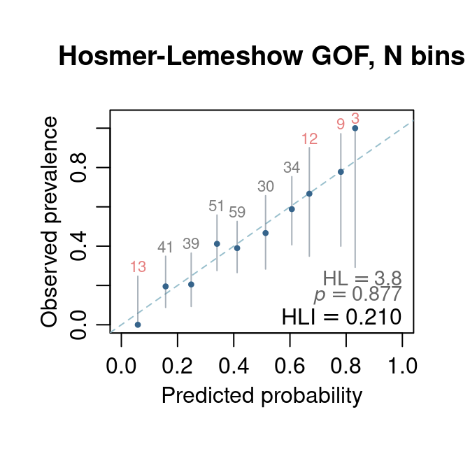

```r
HLfit(model = mod, bin.method = "n.bins", main = "Hosmer-Lemeshow GOF, N bins")
```

Notice the red triangles in the Boyce plots and the red numbers in the Hosmer-Lemeshow plots, which denote bins with overly small sample sizes, for which the comparison between median prediction and random expectation may not be meaningful.

## Evaluating multiple models

You can calulate a set of **evaluation measures for several models simultaneously**, if you have them in a list like *rotif.mods$models* (results not shown here):

```r
model_eval <- multModEv(models = rotif.mods$models, thresh = "preval", bin.method = "quantiles")
model_eval
```

With the *multModEv* function, if you want to use observed and predicted values rather than a list of model objects, get all your values in a table and call them by their column index numbers – e.g., if your observed data are in columns 2 to 8 and your predicted data are in columns 9 to 15 (note that species must be **in the same order** on both *observed* and *predicted* columns!), you can use this command:

```r
multModEv(obs.data = mydata[ , 2:8], pred.data = mydata[ , 9:15], bin.method = "quantiles", thresh = "preval")
```

If you’ve successfully executed any of the two commands above, you can save these results to a file on your disk. The following command will save a comma-separated values (CSV) file in your working directory (type `getwd()` to find out where it is):

```r
write.csv(model_eval, file = "model_eval.csv", row.names = FALSE)
```

## Additional options

Some other potentially useful *modEvA* functions are (still) not covered in this tutorial, but you can find out about them as well:

```r
help(predDensity)
help(predPlot)
help(evenness)
help(prevalence)
help(OA)
help(MESS)
help(varPart)
```

You can find out additional options and further info on any function with *help(function.name)* (e.g., `help(multModEv)`).

That’s it! You can [contact me](https://modtools.wordpress.com/barbosa) with any suggestions or concerns, but first remember to check for updates to the package or to this tutorial at http://modEvA.r-forge.r-project.org. This tutorial was built with *RStudio* + *rmarkdown* + *knitr*. Thanks!